# **A Default Bayes Factor for testing Null Hypotheses About the Fixed Effects of Linear Two-level Models**: A Tutorial

Nikola Sekulovski

# **Introduction**

This tutorial presents a comprehensive and detailed version of the examples section from my master’s thesis (Sekulovski & Hoijtink, 2023). The paper introduces a default Bayes factor (henceforth abbreviated as BF, Kass & Raftery, 1995) with clear operating characteristics for testing whether the fixed effects of linear two-level models are equal to zero. This was achieved by generalizing an approach for linear regression presented in Hoijtink (2021), resulting in a BF of 19 when the marginal $R^2$ for the fixed effects is zero in the data. A `wrapper function` for the `R` package `bain` (Gu et al., 2021) was developed for testing the fixed parameters of linear two-level models fitted with the `lmer` function from the `R` package `lme4` (Bates et al., 2015). The function includes an adjustment for the fraction of the scaling parameter of the prior distribution, as proposed in my paper. Researchers can access the function and the full paper from [this](https://github.com/sekulovskin/research-archive-masters-thesis) repository. This tutorial also provides a step-by-step guide for calculating the Multiple Imputation-based effective sample Size (abbreviated as MI-based $N_{eff}$), a new method for determining the effective sample size for two-level models containing predictors with varying slopes. In the paper, I demonstrate that the sample size does not impact the calculation of the BF. However, I believe that the proposed method for determining the effective sample size of two-level models is an innovative approach. That’s why I have included a comprehensive, step-by-step guide on how to calculate the MI-based $N_{eff}$. Unfortunately, at this time, there is not a user-friendly R function readily available that automates this calculation.

The tutorial aims to:

- Offer practical examples for using the `wrapper function`.
- Demonstrate the clear operating characteristics of the proposed Bayes factor when testing fixed effects in two-level models
- Provide a clear and easy-to-follow guide for calculating the $N_{eff}$. Which represents a promising new approach for calculating the effective sample size for two-level models.

# **Packages**

```r
library(R2MLwiN)      # includes the data set
library(lme4)         # fitting two-level models
library(tidyverse)    # data manipulation and plotting
library(jtools)       # model summaries & automatic calculation of R^2_m
library(summarytools) # descriptive statistics
library(DT)           # interactive tables

# for the MI-based N_eff
library(rjags)
library(MASS)

#the wrapper function
source("wrapper_function.R")
```

Please note, that you need to have [`JAGS`](https://mcmc-jags.sourceforge.io/) installed on your local machine to be able to compute the MI-based $N_{eff}$.

# The wrapper function

```r
bain_2lmer(x, hypotheses, standardize = FALSE,
                       N, fraction, jref = FALSE, seed)
```

As illustrated in the example call above, the `wrapper` takes the following arguments:

- `x`: the fitted `lmer` object;
- `hypotheses`: the specified hypotheses (saved as a character vector), the names of the parameters specified in the hypotheses should correspond to the names of the predictors as specified when calling `lmer` (see the examples below);
- `standardize`: a logical argument, indicating whether to compute the BF based on standardized data. This is not relevant when testing whether the fixed effects are *equal to zero*, however, as mentioned in the paper, it is important when comparing the parameters to each other;
- `N`: the value for the sample size, which includes the following options:
  - `"level_1"` - computes the BF using the number of level-1 observations;
  - `"level_2"` - computes the BF using the number of level-2 observations;
  - `"ICC_effective"` - computes the BF using the ICC based $N_{eff}$;
  - a number supplied by the user - used for the MI-based $N_{eff}$.
- `fraction`: a multiplicative factor for the fraction *b* which is by default set to 1 i.e., the default value for J (the number of fixed effects that are set equal to zero in the hypothesis);
- `jref`: a logical argument, which, if set to equal `TRUE`, applies the calculation for the reference value for $J$ (i.e., $J_{ref}$), which yields BFs with clear operating characteristics when testing whether the fixed effects are equal to zero. In this case, the previous argument `fraction` is ignored (and the used need not specify it).

For more details on how to test (informative) hypotheses for different statistical models, see [this](https://cran.r-project.org/web/packages/bain/vignettes/Introduction_to_bain.html) vignette.

# **The Data**

Throughout the examples, we will be using the `tutorial` data, a two-level data set available from the `R` package `R2MLwiN`. The data represents a subset from a larger data set of examination results from six inner London Education Authorities with 4059 students nested within 65 schools. The variables used for the aims of this example are: (i) the standardized students’ exam score (`normexam`) which will serve as the outcome variable; (ii) the standardized students’ score at age 11 on the London Reading Test (`standlrt`); (iii) the school indicator (`school`) with 65 schools of varying size. Additionally, in the end, a level-2 predictor in the form of the average LRT score for each school (`avslrt`) is included to illustrate that this approach can also be for testing the coefficients of second-level variables.

## Load and inspect the data

```r
data("tutorial")

tutorial.1 <- tutorial[, c(1,2,3,5)] # subset the data with only the variables of interest

st_options(descr.silent = TRUE)
descr(tutorial.1, stats = c("mean", "med", "sd", "min", "max")) # descriptive statistics for the outcome and the level-1 predictor
```

```
## Descriptive Statistics
## tutorial.1
## N: 4059
##
##                 normexam   standlrt
## ------------- ---------- ----------
##          Mean       0.00       0.00
##        Median       0.00       0.04
##       Std.Dev       1.00       0.99
##           Min      -3.67      -2.93
##           Max       3.67       3.02
```

# **Example 1:** Model with random intercept and a random level-1 predictor where $H_0$ is false.

For this example, we fit a two-level model containing a random intercept and a random slope for the `standlrt` variable, i.e.,

$$\text{normexam}_{ij} = \alpha +
\beta_1\;\text{standlrt}_{ij} + u_{0j} + u_{1j}\;\text{standlrt}_{ij} +
\epsilon_{ij},$$
where $i$ = 1,. . . , *N* and $j$ = 1,. . . , *G* with *N* denoting the number of students (level-1 observations i.e., 4059) and *G* denoting the total number of schools (level-2 observations i.e., 65). $\alpha$ represents the fixed intercept, $\beta_1$ represents the effect for `standlrt`, $u_{0j}$ represents the random component denoting the deviation of school $j$ from the fixed intercept and $u_{1j}$ denotes the deviation of school $j$ from the fixed intercept. Lastly, $\epsilon_{ij}$ represents the standard residual error term for student $i$ in school $j$. $u_{0j}$, $u_{1j}$ and $\epsilon_{ij}$ have estimated variance components denoted as $\sigma^2_{u0}$, $\sigma^2_{u1}$ and $\sigma^2_\epsilon$, respectively.

First, let’s visualize this model by plotting the predictor `standlrt` against the outcome `normexam`, with separate regression lines for each school:

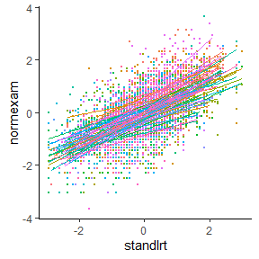

We can see that the schools indeed have different slopes for the predictor `standlrt`. So, let’s fit this model with `lmer`.

## Fit the model

We will estimate all the models using *Full Maximum Likelihood Estimation* (FML), [here](https://towardsdatascience.com/maximum-likelihood-ml-vs-reml-78cf79bef2cf) is an interesting blog post about the differences between FML and REML. However, researchers are advised to use whichever method they choose based on other methodological considerations which are not related to testing the fixed effects. As shown in the paper, the estimation method has a negligible influence on the value of the BF.

```r
model.1 <- lmer(normexam ~ standlrt + (standlrt | school), REML = FALSE, data = tutorial.1)
```

### Inspect the estimates and calculate $R^2_m$

```r
summ(model.1)
```

| Observations | 4059 |
| --- | --- |
| Dependent variable | normexam |
| Type | Mixed effects linear regression |

| AIC | 9328.87 |
| --- | --- |
| BIC | 9366.72 |
| Pseudo-R² (fixed effects) | 0.32 |
| Pseudo-R² (total) | 0.43 |

| Fixed Effects | Fixed Effects Est. | Fixed Effects S.E. | Fixed Effects t val. | Fixed Effects d.f. | Fixed Effects p |
| --- | --- | --- | --- | --- | --- |
| (Intercept) | -0.01 | 0.04 | -0.29 | 65.28 | 0.78 |
| standlrt | 0.56 | 0.02 | 27.62 | 62.60 | 0.00 |

p values calculated using Kenward-Roger standard errors and d.f.

| Random Effects Group | Random Effects Parameter | Random Effects Std. Dev. |
| --- | --- | --- |
| school | (Intercept) | 0.30 |
| school | standlrt | 0.12 |
| Residual |  | 0.74 |

| Grouping Variables Group | Grouping Variables # groups | Grouping Variables ICC |
| --- | --- | --- |
| school | 65 | 0.14 |

The fixed effect for `standlrt` is estimated to be larger than zero, which is evident both by its SE and by the highly significant p-value (rejecting the null hypothesis which states that the fixed effect is equal to zero). The value for the ICC in this data set is .14, which indicates the amount of within-school clustering with respect to `normexam`, before accounting for (part of) the explained variance by introducing (random) predictors.

#### $R^2_m$ using `summ()`

From the table above we can see that the Pseudo-$R^2$ (fixed effects) i.e., the $R^2_m$ is .32, which indicates a large effect size based on Cohen (1992) for the $R^2$ of multiple linear regression.

#### $R^2_m$ by hand

We can also manually compute the marginal $R^2$ which is defined as the proportion of variation in the outcome variable that can be explained by the fixed effect(s):

$$R^2_m = \frac{\sigma_f^2}{\sigma_f^2 +
\sigma_{u0}^2 + \sigma_{u1}^2 + \sigma_\epsilon^2},$$
where $\sigma_f^2$ is calculated is defined as

$$\sigma_f^2 = \text{var}(\alpha
+\beta_1\;\text{standlrt}_{ij}).$$

```r
fixef <- fixef(model.1)  # extract the fixed effect
y_hat <- fixef[1] + fixef[2]*tutorial$standlrt # predict the outcome

sigma_f  <- var(y_hat) # obtain the variance in the predicted outcome based on the fixed effect

# extract the estimated random effects from the fitted model (you can use the summary function)
# i.e., summary(model.1)
sigma_u0 <- 0.09044
sigma_u1 <- 0.01454
sigma_e  <- 0.55366

# calculate the R^2_m
marginal_Rsq_fixed <- (sigma_f)/(sigma_f + sigma_u0 + sigma_u1 + sigma_e)
marginal_Rsq_fixed
```

```
## [1] 0.3170484
```

We can see that this value corresponds to the Pseudo-$R^2$ (fixed effects) given by the `summ` function. Thus, we expect the BF reject the null (i.e., show support for the unconstrained hypothesis).

## Calculate the MI-based $N_{eff}$

In the following section, I will provide a comprehensive, yet easy-to-follow guide on how to compute the recently proposed effective sample size using the tutorial data. While there may be more sophisticated and streamlined methods from a programming perspective, the goal of this tutorial is to clearly demonstrate the underlying processes involved in calculating Mi-based $N_eff$ in a straightforward manner.

First, we need to specify the same model in `JAGS` in a text file:

```r
jags.model <-  "model {
# Likelihood
for (i in 1:4059){
  normexam[i] ~ dnorm(mu[i], tau)
  mu[i] <- alpha[school[i]] + beta[school[i]] * standlrt[i]
}

# Level-2
for(j in 1:65){
alpha[j] <- U[j,1]
beta[j]  <-  U[j,2]
U[j,1:2] ~ dmnorm (MU[j,], invSigma[,])
MU[j,1] <- mu.alpha
MU[j,2] <- mu.beta
}

# (hyper)Priors
mu.alpha ~ dnorm(0, 0.0001)
mu.beta  ~ dnorm(0,  0.0001)
tau ~ dgamma (0.001, 0.001)            # resiudal variance
invSigma[1:2,1:2] ~ dwish(Tau, 2)      # inverse of the covariance matrix following a Wishart prior
  tau.alpha ~ dgamma (0.001, 0.001)    # intercept variance
  tau.beta  ~ dgamma (0.001, 0.001)    # slope variance
  Tau[1,1] <- pow(tau.alpha, -1/2)     # construct the scale matrix (a parameter of the Whishart prior)
  Tau[2,2] <- pow(tau.beta, -1/2)
  Tau[1,2] <- rho_1*tau.alpha*tau.beta # covariance between the slope of standlrt and the intrcept
  Tau[2,1] <- Tau[1,2]
  rho_1 ~ dunif(-1, 1)                 # correlation (between -1 and 1) not important
}
"
```

### Compare the models

Since we are using uninformative priors, we will take a small detour and show that the Bayesian posterior parameter estimates correspond to those obtained with `lmer` when using FML.

```r
# Check and inspect the model
model.def <- jags.model(file = textConnection(jags.model),
                        inits = list(.RNG.name="base::Wichmann-Hill",
                                     .RNG.seed=100),
                        data = tutorial, n.chains = 2)
update(object = model.def, n.iter = 1000)

# ask only for these parameters
parameters <- c("mu.alpha", "mu.beta", "tau", "invSigma")

results <- coda.samples(model = model.def, variable.names = parameters, n.iter =1000)
summary(results)
```

```
##
## Iterations = 2001:3000
## Thinning interval = 1
## Number of chains = 2
## Sample size per chain = 1000
##
## 1. Empirical mean and standard deviation for each variable,
##    plus standard error of the mean:
##
##                    Mean       SD  Naive SE Time-series SE
## invSigma[1,1]  13.52115  3.58318 0.0801224      0.1558283
## invSigma[2,1] -16.27213  8.90956 0.1992239      0.5807041
## invSigma[1,2] -16.27213  8.90956 0.1992239      0.5807041
## invSigma[2,2]  79.44014 31.90626 0.7134457      2.1708230
## mu.alpha       -0.01271  0.04361 0.0009752      0.0013995
## mu.beta         0.55412  0.02121 0.0004743      0.0008501
## tau             1.80630  0.04071 0.0009103      0.0009105
##
## 2. Quantiles for each variable:
##
##                    2.5%       25%       50%       75%     97.5%
## invSigma[1,1]   8.05983  11.05483  13.07467  15.39220  22.17893
## invSigma[2,1] -39.38018 -20.46357 -14.63042 -10.09460  -4.02706
## invSigma[1,2] -39.38018 -20.46357 -14.63042 -10.09460  -4.02706
## invSigma[2,2]  37.66881  57.83871  72.84995  93.21918 170.70371
## mu.alpha       -0.09981  -0.04166  -0.01324   0.01561   0.06769
## mu.beta         0.51329   0.53977   0.55368   0.56767   0.59710
## tau             1.72764   1.77944   1.80671   1.83268   1.89180
```

```r
#transform the precisions of the random eff. into standard deviations
sqrt(1/13.52115) # intercept SD
```

```
## [1] 0.2719526
```

```r
sqrt(1/79.44014) # slope SD
```

```
## [1] 0.1121967
```

```r
sqrt(1/1.8063)   # residual SD
```

```
## [1] 0.744055
```

Note how the posterior mean estimates along with their standard deviations roughly correspond to their (Full) Maximum Likelihood counterparts. Note, the (co)variance components are expressed in terms of precisions, the reason for this are beyond the scope of the tutorial. Thus, in order to be able to compare the results with the ones from `lmer`, we need to take the inverse for the values of `invSigma` and `tau`, and then take the square root (since the random effects summarized by the `summ` function are expressed as standard deviations). The last three rows from the output contain the estimated random effects expressed in terms of standard deviations.

### Obtain multiple imputed data sets

Now, we estimate the model again and save all the sampled random effects, which we will treat as multiple imputed values. We run the sampler by using two chains with a 1000 iterations each (excluding the burn-in period of a 1000 extra iterations).

```r
# fit the model again but ask to monitor all the random effects
model.def <- jags.model(file = textConnection(jags.model),
                        inits = list(.RNG.name="base::Wichmann-Hill",
                                     .RNG.seed=100),
                        data = tutorial, n.chains = 2)
update(object = model.def, n.iter = 1000)

# the random effects (the ones we need for the aim of this approach)
parameters <- c("alpha", "beta", "mu.alpha", "mu.beta")

results <- coda.samples(model = model.def, variable.names = parameters, n.iter =1000)
```

Extract the samples from the posterior (from both chains):

```r
chain1 <- as.data.frame(results[[1]])
chain2 <- as.data.frame(results[[2]])
samples <- rbind(chain1, chain2) # combine both chains
```

Before we start manipulating the sampled random (and fixed) effects, such that we can add each one to a copy of the original data set, it would be nice to have a glimpse of the data set’s layout.

```r
datatable(tutorial.1, options = list(pageLength = 5))
```

|  | school | student | normexam | standlrt |
| --- | --- | --- | --- | --- |
| 1 | 1 | 1 | 0.261324465274811 | 0.619059264659882 |
| 2 | 1 | 2 | 0.134066790342331 | 0.205801963806152 |
| 3 | 1 | 3 | -1.72388243675232 | -1.36457574367523 |
| 4 | 1 | 4 | 0.967585980892181 | 0.205801963806152 |
| 5 | 1 | 5 | 0.544340908527374 | 0.371104866266251 |
| 6 | 1 | 6 | 1.73489916324615 | 2.18943691253662 |
| 7 | 1 | 7 | 1.03960800170898 | -1.11662137508392 |
| 8 | 1 | 8 | -0.129084676504135 | -1.03396987915039 |
| 9 | 1 | 9 | -0.939377665519714 | -0.538061201572418 |
| 10 | 1 | 10 | -1.21948552131653 | -1.44722723960876 |

[output cut: 4049 more lines]

**Extract the fixed effect from each sampled vector (i.e., $\alpha$ and $\beta)$:**

```r
fixed_alphas <- samples[, 131]
fixed_betas <- samples[, 132]
fixed_alphas <- as.data.frame(fixed_alphas)
fixed_betas <- as.data.frame(fixed_betas)
```

Repeat each fixed effect N times (in this case 4059 - the number of $N_{level-1}$ observations) and store it in a separate data frame that will be merged with the imputed data sets later on:

```r
# the fixed intercepts
samp_fixed_alphas <- list()
for (i in 1:nrow(fixed_alphas)){
   samp_fixed_alphas[[i]] <-rep.int(fixed_alphas[i, 1], nrow(tutorial.1))
}

# the fixed slopes
samp_fixed_betas <- list()
for (i in 1:nrow(fixed_betas)){
   samp_fixed_betas[[i]] <-rep.int(fixed_betas[i, 1], nrow(tutorial.1))
}
```

**Get the sampled random intercepts ($\alpha_j's$)**

First, split the data per group:

```r
split <- split(tutorial.1, tutorial.1$school)
```

Afterwards, extract the size of each group:

```r
n_gr <- sapply(split, nrow)
```

Exclude the columns containing the fixed effects from the `samples` data set:

```r
samples <- samples[, -c(131,132)]
```

Extract the random $\alpha_{j}s$ and $\beta_{j}s$ into separate data frames:

```r
alphas <- samples [, 1:65]  # extract the random intercepts
betas <- samples [, 66:130] # extract the random slopes
```

Use the size of each group to replicate, from each iteration, the respective $\alpha_j$, `n_gr` number of times:

```r
samp_alphas <- list()

for (i in 1:nrow(alphas)){
   samp_alphas[[i]] <-rep.int(alphas[i, ], n_gr)
}
```

Extract these in a big matrix with the samples from every iteration stored in a separate column:

```r
samp_alphas_mat <- matrix(nrow = nrow(tutorial.1), ncol = nrow(alphas))

for(i in 1:nrow(alphas)){
  samp_alphas_mat[, i] <- unlist(samp_alphas[[i]])
}
```

**Get the sampled random slopes ($\beta_j's$)**

Use the size of each group to replicate, from each iteration, the respective $\beta_j$, `n_gr` number of times:

```r
samp_betas <- list()

for (i in 1:nrow(betas)){
   samp_betas[[i]] <-rep.int(betas[i, ], n_gr)
}
```

Extract them in a big matrix with the samples from every iteration stored in a separate column:

```r
samp_betas_mat <- matrix(nrow = nrow(tutorial.1), ncol = nrow(betas))

for(i in 1:nrow(betas)){
  samp_betas_mat[, i] <- unlist(samp_betas[[i]])
}
```

**Combine the sampled random effects**

First, combine the $\alpha_j's$:

```r
imputed <- list()

for (i in 1:ncol(samp_alphas_mat)){
  imputed[[i]] <- cbind(tutorial.1, samp_alphas_mat[, i])
}
```

Add the $\beta_j's$:

```r
for (i in 1:ncol(samp_betas_mat)){
  imputed[[i]] <- cbind(imputed[[i]], samp_betas_mat[, i])
}
```

**Add the sampled fixed effects:**

The $\alpha's$:

```r
for (i in 1:length(imputed)){
  imputed[[i]] <- cbind(imputed[[i]], samp_fixed_alphas[[i]])
}
```

The $\beta's$:

```r
for (i in 1:length(imputed)){
  imputed[[i]] <- cbind(imputed[[i]], samp_fixed_betas[[i]])
}
```

Voilà, we obtained 2000 imputed data sets.

### Transform the outcome variable

In order to be able to fit multiple linear regression models we need to transform the outcome variable as follows,

$$Z_{ij} = \text{normexam}_{ij} - \alpha_j
- \beta_j\;\text{standlrt}_{ij} + \alpha +
\beta\;\text{standlrt}_{ij},$$

which leads to
$$Z_i = \eta_0 +
\eta_1\;\text{standlrt}_i + e_i.$$

Construct a function that calculates $Z$:

```r
transform_z <- function(df){
  df$z <- df[, 3] - df[, 5] - df[, 6] * df[, 4] + df[, 7] + df[, 8] * df[, 4]
  df
}
```

Apply the function to the “imputed” data sets and obtain a column for $Z$:

```r
imputed <- lapply(imputed, transform_z)
```

Now let’s quickly have a look at one of the imputed data sets:

```r
datatable(imputed[[1]][,-c(1,2)], options = list(pageLength = 5)) # exclude the school and student columns
```

|  | normexam | standlrt | samp_alphas_mat[, i] | samp_betas_mat[, i] | samp_fixed_alphas[[i]] | samp_fixed_betas[[i]] | z |
| --- | --- | --- | --- | --- | --- | --- | --- |
| 1 | 0.261324465274811 | 0.619059264659882 | 0.360972734786922 | 0.582247898710767 | -0.0944693860464581 | 0.522905716691501 | -0.230853983122729 |
| 2 | 0.134066790342331 | 0.205801963806152 | 0.360972734786922 | 0.582247898710767 | -0.0944693860464581 | 0.522905716691501 | -0.333588068087157 |
| 3 | -1.72388243675232 | -1.36457574367523 | 0.360972734786922 | 0.582247898710767 | -0.0944693860464581 | 0.522905716691501 | -2.09834765542545 |
| 4 | 0.967585980892181 | 0.205801963806152 | 0.360972734786922 | 0.582247898710767 | -0.0944693860464581 | 0.522905716691501 | 0.499931122462694 |
| 5 | 0.544340908527374 | 0.371104866266251 | 0.360972734786922 | 0.582247898710767 | -0.0944693860464581 | 0.522905716691501 | 0.0668766151717866 |
| 6 | 1.73489916324615 | 2.18943691253662 | 0.360972734786922 | 0.582247898710767 | -0.0944693860464581 | 0.522905716691501 | 1.14953107862933 |
| 7 | 1.03960800170898 | -1.11662137508392 | 0.360972734786922 | 0.582247898710767 | -0.0944693860464581 | 0.522905716691501 | 0.650428629762437 |
| 8 | -0.129084676504135 | -1.03396987915039 | 0.360972734786922 | 0.582247898710767 | -0.0944693860464581 | 0.522905716691501 | -0.523168768566534 |
| 9 | -0.939377665519714 | -0.538061201572418 | 0.360972734786922 | 0.582247898710767 | -0.0944693860464581 | 0.522905716691501 | -1.36289006059188 |
| 10 | -1.21948552131653 | -1.44722723960876 | 0.360972734786922 | 0.582247898710767 | -0.0944693860464581 | 0.522905716691501 | -1.58904601987381 |

[output cut: 4049 more lines]

**Estimates:**

Fit linear regression models to each imputed data set and extract the estimated coefficients and their respective variance-covariance matrices:

```r
estimates <- list()
vCOV <- list()
for(i in seq_along(imputed)){
  estimates[[i]] <- coef(lm(imputed[[i]][,9] ~ imputed[[i]][,4]))
  vCOV [[i]] <- vcov(lm(imputed[[i]][,9] ~ imputed[[i]][,4]))
}
```

Extract these estimates in a data frame:

```r
estimates <- unlist(estimates)
intercepts <- estimates[seq(1,length(estimates),2)] # select every other element
slopes <- estimates[seq(2,length(estimates),2)]     # opposite
estimates <- data.frame(intercepts, slopes)         # combine
```

### Apply the multiple imputation equations

The following equations are taken from Van Buuren (2018, Ch. 2.3).

```r
m <- nrow(estimates) # number of "imputations" (i.e., iterations in this case)
```

**Combined estimate:**

$$\bar{\boldsymbol{\eta}} = \frac{1}{m}
\sum_{l = 1}^{m} \hat{\boldsymbol{\eta}_l}$$

```r
eta_bar <- apply(estimates, 2, mean)
eta_bar <- t(eta_bar)
eta_bar <- as.matrix(eta_bar)
```

**Average over the variances:**

$$\bar{U} = \frac{1}{m} \sum_{l = 1}^{m}
\bar{U}_l$$

Since the list `vCOV` contains variance-covariance matrices and we need to take the average across all of them (and not within them), it is best to extract every element of each covariance matrix and then take the average:

```r
V <- matrix(nrow = nrow(estimates), ncol = 4)

for(i in seq_along(vCOV)){
  V[i, 1] <- vCOV[[i]][1,1]
  V[i, 2] <- vCOV[[i]][1,2]
  V[i, 3] <- vCOV[[i]][2,1]
  V[i, 4] <- vCOV[[i]][2,2]
}

U_bar <- apply(V, 2, mean)
U_bar <- matrix(U_bar, nrow = 2, ncol = 2)
```

**Unbiased estimate of the variance between the m complete data estimates:**

$$B = \frac{1}{m-1} \sum_{l = 1}^{m}
(\hat{\boldsymbol{\eta}}_l -
\bar{\boldsymbol{\eta}})(\hat{\boldsymbol{\eta}}_l -
\bar{\boldsymbol{\eta}})'.$$

```r
B <- cov(estimates)
```

**Total variance:**

$$T = \bar{U} + (1 +
\frac{1}{m})*B$$

```r
Total_var <- U_bar + (1 + 1/m)*B
```

**Proportion of variation attributable to the missing data (a compromise over all estimates)**

$$\bar{\lambda} =(1 + \frac{1}{m})
tr(BT^{-1})/k$$

```r
k <- ncol(estimates) # number of parameters in eta_hat
lambda_hat <- (1+ 1/m) * sum(diag(B %*% ginv(Total_var)))/k
```

**Degrees of freedom:**

$$\nu_{old} = \frac{m-1}{\bar{\lambda}^2};
\; \nu_{com} = N_{level-1} - k; \; \nu_{obs} = \frac{\nu_{com} +
1}{\nu_{com} + 3}\nu_{com}(1-\bar{\lambda}); \; \nu = \frac{\nu_{old}
\nu_{obs}}{\nu_{old} + \nu_{obs}}.$$

```r
N <- nrow(tutorial.1) # N_level-1

nu_old <- (m - 1)/lambda_hat^2

nu_com <- N - k

nu_obs <- ((nu_com +1)/(nu_com + 3))*nu_com*(1 - lambda_hat)

nu <- (nu_old*nu_obs)/(nu_old + nu_obs)
```

**Fraction of missing information:**

$$\gamma = \frac{\nu + 1}{\nu +
3}\bar{\lambda}+\frac{2}{\nu + 3}$$

```r
gamma <- ((nu + 1)/(nu + 3)) * lambda_hat + (2/(nu + 3))
```

**Calculate the MI-based $N_{eff}$**

$$\text{MI-based}\; N_{eff} = N_{level-1}
- \gamma*N_{level-1}$$

```r
MI_N_eff <- N - gamma*N
MI_N_eff
```

```
## [1] 874.2342
```

The MI-based effective sample size is 874.

### Compare with the ICC-based $N_{eff}$

**Calculate the ICC-based $N_{eff}$**

```r
# fit a random intercept-only model
model.0 <- lmer(normexam ~1 + (1|school), REML = FALSE, data = tutorial.1)
summary(model.0)
```

```
## Linear mixed model fit by maximum likelihood  ['lmerMod']
## Formula: normexam ~ 1 + (1 | school)
##    Data: tutorial.1
##
##      AIC      BIC   logLik deviance df.resid
##  11016.6  11035.6  -5505.3  11010.6     4056
##
## Scaled residuals:
##     Min      1Q  Median      3Q     Max
## -3.9471 -0.6486  0.0117  0.6992  3.6578
##
## Random effects:
##  Groups   Name        Variance Std.Dev.
##  school   (Intercept) 0.1686   0.4107
##  Residual             0.8478   0.9207
## Number of obs: 4059, groups:  school, 65
##
## Fixed effects:
##             Estimate Std. Error t value
## (Intercept) -0.01317    0.05363  -0.246
```

```r
ICC <- 0.1686 / (0.1686 + 0.8478)
ICC
```

```
## [1] 0.1658796
```

The ICC-based $N_{eff}$ is defined as

$$\text{ICC-based} \; N_{eff} =
\frac{N_{level-1}}{1+(n_c - 1)ICC},$$

where $n_c$ denotes the within-group sample size. As already mentioned, a drawback of the ICC-based $N_{eff}$ is that when the data has varying group sizes, a compromise, such as taking the average group size, has to be made.

```r
n_clus <- mean(sapply(split, nrow)) # the average group (i.e., school) size (62.4 in this case)
ICC_N_eff <- N / (1 + (n_clus - 1) * ICC)
ICC_N_eff
```

```
## [1] 362.6483
```

The value of the ICC-based effective sample size is 363. This demonstrates that by accounting for the within-group variation through a model that includes a random intercept and random slope for the predictor `standlrt`, the number of effective level-1 observations increases from 362 to 874. Essentially, the model with the predictor “explains away” some of the clustering within groups indicated by the ICC. As an exercise, you may want to try recalculating the MI-based effective sample size by using a random intercept-only model with JAGS, and compare the value obtained to that of the ICC-based approach.

## Test the fixed effects using the BF

For the aims of this example we test a null hypothesis stating that the fixed effect for `standlrt` is *equal* to zero and a simple inequality constrained (informative) hypothesis stating that the fixed effect is *larger* than zero:

$$H_0: \beta_1 = 0; \; H_i:\beta_1
>0.$$

We define these hypotheses in one single character vector (note the names correspond to the variable names used when calling `lmer`):

```r
hypotheses <- "standlrt = 0;
               standlrt > 0"
```

Now we call the `wrapper function` with the calculated MI-based $N_{eff}$ for the sample size and `ref` set to `TRUE`:

```r
BFs.1 <- bain_2lmer(model.1, hypotheses, standardize = FALSE,
                    N = MI_N_eff, seed = 123, jref = TRUE)
print(BFs.1)
```

```
## Bayesian informative hypothesis testing for an object of class numeric:
##
##    Fit   Com   BF.u  BF.c               PMPa  PMPb  PMPc
## H1 0.000 1.053 0.000 0.000              0.000 0.000 0.000
## H2 1.000 0.500 2.000 22919082073133.293 1.000 0.667 1.000
## Hu                                            0.333
## Hc 0.000 0.500 0.000                                0.000
##
## Hypotheses:
##   H1: standlrt=0
##   H2: standlrt>0
##
## Note: BF.u denotes the Bayes factor of the hypothesis at hand versus the unconstrained hypothesis Hu. BF.c denotes the Bayes factor of the hypothesis at hand versus its complement. PMPa contains the posterior model probabilities of the hypotheses specified. PMPb adds Hu, the unconstrained hypothe…
```

```r
#take the inverse of BF_ou

BFu0 <- 1/BFs.1[["fit"]]$BF[1]
BFu0
```

```
## [1] 1.092365e+168
```

The $BF_{iu}$ is around 2, which indicates that the support in the data is two times in favour of $H_i$. Additionally, we can easily obtain the BF of the informative hypothesis against the null hypothesis, by taking the ratio of their respective BFs against the unconstrained hypothesis. In this case $BF_{iu} =2.5\text{e+}181$.

```r
# Get BF_i0
BF_iu <- BFs.1[["fit"]]$BF[2]/BFs.1[["fit"]]$BF[1]
BF_iu
```

```
## [1] 2.5036e+181
```

Finally, we inspect the value for the *fraction b*:

```r
BFs.1$b
```

```
## [1] 0.002770083
```

The value for the *fraction b* is smaller than 0.05, allowing us to interpret the resulting BFs as *Approximate BFs*. Thus, we say: using the default AAFBF (Gu et al., 2018) set to equal 19 when the *marginal* $R^2$ for the fixed effects is zero in the data (Hoijtink, 2021), the *approximate* BF of the informative hypothesis against the null hypothesis is $2.5\text{e+}181$, and we conclude that *given the data*, the fixed coefficient for the predictor `standlrt` is larger than zero.

# **Example 2:** Model with random intercept and a random level-1 predictor where $H_0$ is true.

## Simulate the data where $H_0$ is true

In order to further clarify the operating characteristics of this BF, we simulate the outcome `normexam` by having the fixed effect for `standlrt` equal to zero and redo all the analyses.

```r
set.seed(123) # set a random seed to make the results reproducible

nG <- 65  # number of schools
b <- 0   # new coefficient

# simulate the random effects (using the estimated variances from model.1)
intercept_var <- rnorm(nG, 0, 0.3)
u_0 <- rep(intercept_var, times = n_gr)
slope_var_1 <- rnorm(nG, 0, 0.1)
u_1 <- rep(slope_var_1, times = n_gr)
# same with the residual variance
epsilon <- rnorm(4059, 0, 0.7)

# calculate the new outcome
normexam <-  b *tutorial$standlrt +  u_0 + u_1*tutorial$standlrt + epsilon

# put everything together in a new df
tutorial.2 <- data.frame(tutorial$school, tutorial$student, normexam, tutorial$standlrt)
names(tutorial.2) <- c("school", "student", "normexam", "standlrt")
```

## Fit the model

```r
model.2<- lmer(normexam ~ standlrt + (standlrt | school), REML = FALSE, data = tutorial.2)
```

### Inspect the parameter estimates and calculate $R^2_m$

```r
summ(model.2)
```

| Observations | 4059 |
| --- | --- |
| Dependent variable | normexam |
| Type | Mixed effects linear regression |

| AIC | 8800.37 |
| --- | --- |
| BIC | 8838.23 |
| Pseudo-R² (fixed effects) | 0.00 |
| Pseudo-R² (total) | 0.16 |

| Fixed Effects | Fixed Effects Est. | Fixed Effects S.E. | Fixed Effects t val. | Fixed Effects d.f. | Fixed Effects p |
| --- | --- | --- | --- | --- | --- |
| (Intercept) | 0.01 | 0.04 | 0.23 | 65.23 | 0.82 |
| standlrt | 0.00 | 0.02 | 0.09 | 61.43 | 0.93 |

p values calculated using Kenward-Roger standard errors and d.f.

| Random Effects Group | Random Effects Parameter | Random Effects Std. Dev. |
| --- | --- | --- |
| school | (Intercept) | 0.29 |
| school | standlrt | 0.10 |
| Residual |  | 0.70 |

| Grouping Variables Group | Grouping Variables # groups | Grouping Variables ICC |
| --- | --- | --- |
| school | 65 | 0.15 |

Note that the value for the fixed effect of `standlrt` is estimated to be zero (this can also be seen from the highly non-significant p-value). Moreover, now $R^2_m = 0$, and we expect that our new default BF will tend towards 19.

Additionally, the ICC is .15 which yields an ICC based $N_{eff}$ of 375 and MI-based $N_{eff}$ of 1070.

## Test the fixed effects using the BF

```r
BFs.2 <- bain_2lmer(model.2, hypotheses, standardize = FALSE,
                    N = 1070, seed = 123, jref = TRUE)
print(BFs.2)
```

```
## Bayesian informative hypothesis testing for an object of class numeric:
##
##    Fit    Com   BF.u   BF.c   PMPa  PMPb  PMPc
## H1 23.062 1.218 18.927 18.927 0.946 0.901 0.904
## H2 0.535  0.500 1.070  1.150  0.054 0.051 0.051
## Hu                                  0.048
## Hc 0.465  0.500 0.930                     0.044
##
## Hypotheses:
##   H1: standlrt=0
##   H2: standlrt>0
##
## Note: BF.u denotes the Bayes factor of the hypothesis at hand versus the unconstrained hypothesis Hu. BF.c denotes the Bayes factor of the hypothesis at hand versus its complement. PMPa contains the posterior model probabilities of the hypotheses specified. PMPb adds Hu, the unconstrained hypothe…
```

The $BF_{0u} = 18.93$ and the $BF_{iu} = 1.1$. In this case, we conclude that *given the data*, the fixed coefficient for the predictor `standlrt` is not different from zero.

```r
# obtain BF_0i.1
BF_0i.1 <- BFs.2[["fit"]]$BF[1]/BFs.2[["fit"]]$BF[2]
BF_0i.1
```

```
## [1] 16.45191
```

```r
# obtain b
BFs.2$b
```

```
## [1] 0.002770083
```

# **Example 3:** Model that includes a level-2 predictor where $H_0$ is false

To illustrate that this approach can also be used when the model contains a continuous level-2 predictor, we add the variable `avslrt` to the model, which represents the average LRT score for each school. Thus, the linear equation for the model becomes:

$$\text{normexam}_{ij} = \alpha +
\beta_1\;\text{standlrt}_{ij} + \beta_{1,2}\;\text{avslrt}_{j}+ u_{0j} +
u_{1j}\;\text{standlrt}_{ij} + \epsilon_{ij},$$

where, $\beta_{1,2}$ denotes the estimated coefficient for the level-2 predictor `avslrt`.

## Fit the model and inspect the $R^2_m$

```r
model.3 <- lmer(normexam ~ standlrt + avslrt + (standlrt | school), REML = FALSE, data = tutorial)
summ(model.3)
```

| Observations | 4059 |
| --- | --- |
| Dependent variable | normexam |
| Type | Mixed effects linear regression |

| AIC | 9324.43 |
| --- | --- |
| BIC | 9368.59 |
| Pseudo-R² (fixed effects) | 0.35 |
| Pseudo-R² (total) | 0.44 |

| Fixed Effects | Fixed Effects Est. | Fixed Effects S.E. | Fixed Effects t val. | Fixed Effects d.f. | Fixed Effects p |
| --- | --- | --- | --- | --- | --- |
| (Intercept) | -0.00 | 0.04 | -0.03 | 65.91 | 0.97 |
| standlrt | 0.55 | 0.02 | 27.09 | 63.16 | 0.00 |
| avslrt | 0.29 | 0.11 | 2.70 | 71.47 | 0.01 |

p values calculated using Kenward-Roger standard errors and d.f.

| Random Effects Group | Random Effects Parameter | Random Effects Std. Dev. |
| --- | --- | --- |
| school | (Intercept) | 0.27 |
| school | standlrt | 0.12 |
| Residual |  | 0.74 |

| Grouping Variables Group | Grouping Variables # groups | Grouping Variables ICC |
| --- | --- | --- |
| school | 65 | 0.12 |

Now, we see that the level-2 predictor is also larger than zero, evident both by the value of the estimate and its respective SE but also by the value of $R^2_m$ which is .35 (compared to .32 when only including `standlrt` as a predictor).

## Test the (fixed) effects using the BF

Now, the hypotheses are defined as follows:

$$H_0: \beta_1 = \beta_{1,2} = 0;
\;H_i:\beta_1 > 0 \; \&\; \beta_{1,2} > 0.$$

```r
hypotheses <- "standlrt = avslrt = 0;
               standlrt > 0 & avslrt > 0"
```

We calculate the BFs by using the ICC-based $N_{eff}$ = 358 (which can be calculated automatically within the `wrapper function`) since the MI-based $N_{eff}$ has not yet been extended to include level-2 predictors and, as shown in the paper, the sample size does not influence the BF when using $J_{ref}$.

```r
BFs.3 <- bain_2lmer(model.3, hypotheses, standardize = FALSE,
                    N = "ICC_effective", seed = 123, jref = TRUE)
print(BFs.3)
```

```
## Bayesian informative hypothesis testing for an object of class numeric:
##
##    Fit   Com   BF.u  BF.c     PMPa  PMPb  PMPc
## H1 0.000 3.946 0.000 0.000    0.000 0.000 0.000
## H2 0.997 0.236 4.222 1239.662 1.000 0.809 0.999
## Hu                                  0.191
## Hc 0.003 0.764 0.003                      0.001
##
## Hypotheses:
##   H1: standlrt=avslrt=0
##   H2: standlrt>0&avslrt>0
##
## Note: BF.u denotes the Bayes factor of the hypothesis at hand versus the unconstrained hypothesis Hu. BF.c denotes the Bayes factor of the hypothesis at hand versus its complement. PMPa contains the posterior model probabilities of the hypotheses specified. PMPb adds Hu, the unconstrained hypothe…
```

```r
BFs.3$b
```

```
## [1] 0.05263158
```

```r
#take the inverse of BF_ou

BFu0 <- 1/BFs.3[["fit"]]$BF[1]
BFu0
```

```
## [1] 1.981648e+167
```

```r
# Get BF_i0
BF_iu <- BFs.3[["fit"]]$BF[2]/BFs.3[["fit"]]$BF[1]
BF_iu
```

```
## [1] 2.456574e+170
```

Additionally, $BF_{u0} \simeq 1.9\text{e+}167$ and $BF_{i0}\simeq 2.4\text{e+}170$.

# **Example 4:** Model that includes a level-2 predictor where $H_0$ is true

Finally, we repeat this analysis again, by simulating the outcome where the coefficients for both the level-1 and the level-2 predictors are zero i.e., the $R^2_m = 0$.

```r
set.seed(12) # set a random seed in order to make the results reproducible

nG <- 65  # number of schools
b <- 0   # new coefficient

# simulate the random effects (using the estimated variances from model.1)
intercept_var <- rnorm(nG, 0, 0.3)
u_0 <- rep(intercept_var, times = n_gr)
slope_var_1 <- rnorm(nG, 0, 0.1)
u_1 <- rep(slope_var_1, times = n_gr)
# same with the residual variance
epsilon <- rnorm(4059, 0, 0.7)
# calculate the new outcome
normexam <-  b *tutorial$standlrt + b*tutorial$avslrt +  u_0 + u_1*tutorial$standlrt + epsilon

# put everything together in a new df
tutorial.3 <- data.frame(tutorial$school, tutorial$student, normexam, tutorial$standlrt, tutorial$avslrt)
names(tutorial.3) <- c("school", "student", "normexam", "standlrt", "avslrt")
```

## Fit the model and inspect the $R^2_m$

```r
model.4 <- lmer(normexam ~ standlrt + avslrt + (standlrt | school), REML = FALSE, data = tutorial.3)
summ(model.4)
```

| Observations | 4059 |
| --- | --- |
| Dependent variable | normexam |
| Type | Mixed effects linear regression |

| AIC | 8934.82 |
| --- | --- |
| BIC | 8978.98 |
| Pseudo-R² (fixed effects) | 0.00 |
| Pseudo-R² (total) | 0.14 |

| Fixed Effects | Fixed Effects Est. | Fixed Effects S.E. | Fixed Effects t val. | Fixed Effects d.f. | Fixed Effects p |
| --- | --- | --- | --- | --- | --- |
| (Intercept) | -0.01 | 0.04 | -0.20 | 65.96 | 0.85 |
| standlrt | -0.01 | 0.02 | -0.35 | 62.44 | 0.73 |
| avslrt | -0.08 | 0.11 | -0.75 | 71.30 | 0.45 |

p values calculated using Kenward-Roger standard errors and d.f.

| Random Effects Group | Random Effects Parameter | Random Effects Std. Dev. |
| --- | --- | --- |
| school | (Intercept) | 0.26 |
| school | standlrt | 0.10 |
| Residual |  | 0.71 |

| Grouping Variables Group | Grouping Variables # groups | Grouping Variables ICC |
| --- | --- | --- |
| school | 65 | 0.12 |

We can now see that the $R^2_m$ = 0, thus we expect the BF to be *in favour* of the null hypothesis.

## Test the (fixed) effects using the BF

```r
BFs.4 <- bain_2lmer(model.4, hypotheses, standardize = FALSE,
                    N = "ICC_effective", seed = 123, jref = TRUE)
print(BFs.4)
```

```
## Bayesian informative hypothesis testing for an object of class numeric:
##
##    Fit    Com   BF.u   BF.c   PMPa  PMPb  PMPc
## H1 58.159 4.527 12.846 12.846 0.978 0.908 0.895
## H2 0.069  0.236 0.294  0.241  0.022 0.021 0.020
## Hu                                  0.071
## Hc 0.931  0.764 1.218                     0.085
##
## Hypotheses:
##   H1: standlrt=avslrt=0
##   H2: standlrt>0&avslrt>0
##
## Note: BF.u denotes the Bayes factor of the hypothesis at hand versus the unconstrained hypothesis Hu. BF.c denotes the Bayes factor of the hypothesis at hand versus its complement. PMPa contains the posterior model probabilities of the hypotheses specified. PMPb adds Hu, the unconstrained hypothe…
```

```r
# calculate BF_ui
BF_0i.2 <- BFs.4[["fit"]]$BF[1]/BFs.4[["fit"]]$BF[2]
BF_0i.2
```

```
## [1] 53.19708
```

```r
# obtain b
BFs.4$b
```

```
## [1] 0.05263158
```

We obtain a $BF_{0u} = 12.8$ and a $BF_{iu} = 0.3$, which translates to a $BF_{0i}= 53.2$. Thus, we can say that the evidence in the data is 53 times in favour of $H_0$ (i.e., that the effects of both `standlrt` and `avslrt` are zero) against $H_i$ (i.e., that the effects of both `standlrt` and `avslrt` are larger than zero).

# Example 5: Model that includes a cross-level interaction

Finally, using the data set with the simulated outcome with no effect of the predictors (used in the preceding example), we estimate a model that includes a cross-level interaction between `standlrt` and `avslrt`.

```r
model.5 <- lmer(normexam ~ standlrt + avslrt + standlrt:avslrt + (standlrt | school), REML = FALSE, data = tutorial.3)
summ(model.5)
```

| Observations | 4059 |
| --- | --- |
| Dependent variable | normexam |
| Type | Mixed effects linear regression |

| AIC | 8933.29 |
| --- | --- |
| BIC | 8983.76 |
| Pseudo-R² (fixed effects) | 0.00 |
| Pseudo-R² (total) | 0.14 |

| Fixed Effects | Fixed Effects Est. | Fixed Effects S.E. | Fixed Effects t val. | Fixed Effects d.f. | Fixed Effects p |
| --- | --- | --- | --- | --- | --- |
| (Intercept) | -0.01 | 0.04 | -0.32 | 66.97 | 0.75 |
| standlrt | -0.00 | 0.02 | -0.18 | 63.31 | 0.86 |
| avslrt | -0.04 | 0.11 | -0.33 | 71.86 | 0.74 |
| standlrt:avslrt | 0.10 | 0.05 | 1.87 | 69.68 | 0.07 |

p values calculated using Kenward-Roger standard errors and d.f.

| Random Effects Group | Random Effects Parameter | Random Effects Std. Dev. |
| --- | --- | --- |
| school | (Intercept) | 0.26 |
| school | standlrt | 0.10 |
| Residual |  | 0.71 |

| Grouping Variables Group | Grouping Variables # groups | Grouping Variables ICC |
| --- | --- | --- |
| school | 65 | 0.12 |

Based on the estimate and its standard error, the cross-level interaction effect is larger than the fixed effects of the two predictors, which leads us to believe that the cross-level interaction is different from zero (it’s also “almost significant” based on its p-value).

In order to formally test this using our proposed framework, we include a second null hypothesis:

$$H_{0_{2}}:\beta_1 = \beta_{1,2} =
\beta_{int} = 0$$
,

where $\beta_{int}$ is the regression coefficient for the interaction term $\text{standlrt}_{ij}*\text{avslrt}_j$.

We keep the other two hypotheses used in Examples 3 and 4 i.e., $H_{0_{1}}: \beta_1 = \beta_{1,2} = 0$ and $H_i:\beta_1 > 0 \; \&\; \beta_{1,2} > 0$.

```r
hypotheses <- "standlrt = avslrt =0;
               standlrt = avslrt = standlrt:avslrt = 0;
               standlrt > 0 & avslrt > 0 & standlrt:avslrt > 0"

BFs.5 <- bain_2lmer(model.5, hypotheses, standardize = F, N = "ICC_effective", seed = 123, jref = TRUE)
print(BFs.5)
```

```
## Bayesian informative hypothesis testing for an object of class numeric:
##
##    Fit    Com    BF.u  BF.c  PMPa  PMPb  PMPc
## H1 79.317 12.052 6.581 6.581 0.683 0.619 0.619
## H2 71.897 34.967 2.056 2.056 0.213 0.193 0.193
## H3 0.145  0.146  0.997 0.997 0.104 0.094 0.094
## Hu                                 0.094
## Hc 0.855  0.854  1.000                   0.094
##
## Hypotheses:
##   H1: standlrt=avslrt=0
##   H2: standlrt=avslrt=standlrt:avslrt=0
##   H3: standlrt>0&avslrt>0&standlrt:avslrt>0
##
## Note: BF.u denotes the Bayes factor of the hypothesis at hand versus the unconstrained hypothesis Hu. BF.c denotes the Bayes factor of the hypothesis at hand versus its complement. PMPa contains the posterior model probabilities of the hypotheses specified. PMPb adds Hu, the unconstrained hypothe…
```

```r
BFs.5$b
```

```
## [1] 0.1404422
```

```r
#calculate BF_ui
BF_0i.4 <- BFs.5[["fit"]]$BF[1]/BFs.5[["fit"]]$BF[2]
BF_0i.4
```

```
## [1] 3.200749
```

We obtain the following results: $BF_{0_{1}u}$ = 6.6, $BF_{0_{2}u}$ = 2.1 and $BF_{iu}$ = 1. Which yields a $BF_{0_{1} 0_{2}}$ = 3.2. Since now the *fraction b* is equal to 0.14, it follows that it should be explicitly stated that the BFs given by `bain`, in this case, are treated as information criteria that are inspired by the BF. However, for all practical purposes, the interpretation of the values for the BFs (as support in the data for one of the hypotheses against the other) remains the same.

Thus, we say that, based on the *information criterion inspired by the BF*, the evidence in the data is 3.2 times in favour of $H_{0_{1}}$ against $H_{0_{2}}$. This means that there is support in the data for the null hypothesis that *only* the fixed effects are equal to zero, whereas the interaction effect is larger than zero.

# **References**

Bates, D., Mächler, M., Bolker, B., & Walker, S. (2015). Fitting linear mixed-effects models using lme4. *Journal of Statistical Software*, *67*(1), 1–48. https://doi.org/10.18637/jss.v067.i01

Cohen, J. (1992). A power primer. *Psychological Bulletin*, *112*(1), 155. https://doi.org/10.1037/0033-2909.112.1.155

Gu, X., Hoijtink, H., Mulder, J., & van Lissa, C. J. (2021). *Bain: Bayes factors for informative hypotheses*. https://CRAN.R-project.org/package=bain

Gu, X., Mulder, J., & Hoijtink, H. (2018). Approximated adjusted fractional bayes factors: A general method for testing informative hypotheses. *British Journal of Mathematical and Statistical Psychology*, *71*(2), 229–261. https://doi.org/10.1111/bmsp.12110

Hoijtink, H. (2021). Prior sensitivity of null hypothesis bayesian testing. *Psychological Methods*. https://doi.org/10.1037/met0000292

Kass, R. E., & Raftery, A. E. (1995). Bayes factors. *Journal of the American Statistical Association*, *90*(430), 773–795. https://doi.org/10.1080/01621459.1995.10476572

Long, J. A. (2020). *Jtools: Analysis and presentation of social scientific data*. https://cran.r-project.org/package=jtools

Luke, S. G. (2017). Evaluating significance in linear mixed-effects models in r. *Behavior Research Methods*, *49*(4), 1494–1502. https://doi.org/10.3758/s13428-016-0809-y

Sekulovski, N., & Hoijtink, H. (2023). A default bayes factor for testing null hypotheses about the fixed effects of linear two-level models. *Psychological Methods*. https://doi.org/10.1037/met0000573

Van Buuren, S. (2018). *Flexible imputation of missing data*. Chapman & Hall/CRC Press. https://doi.org/10.1201/9780429492259